# 543 assignment 2

# Data Source

This assignment would use the same data as the assignment 1.

[figure not shown]

The data source is the same as the data in the first assignment.

```r
link = 'https://raw.githubusercontent.com/tianyl27/543_coursework_2/main/WHR2021.csv'

# getting the data TABLE from the file:
WHRData2021 <- read.csv(file=url(link))
```

#### 1.1 get the data

```r
# get COVID death data
CovidDeath = cbind(WHRData2021[,1:3],WHRData2021[,23])
colnames(CovidDeath) = c('Country', 'Region','Continent', 'DeathRate')

# delete rows with na values: None
CovidDeath = CovidDeath[complete.cases(CovidDeath),]

# order by death rate in 2020 and show the first 20 countries
CovidDeath=CovidDeath[order(-CovidDeath$DeathRate),]
head(CovidDeath,20)
```

|  | Country | Region | Continent | DeathRate |
| --- | --- | --- | --- | --- |
| 140 | Belgium | Western Europe | Europe | 168.496 |
| 2 | Slovenia | Central and Eastern Europe | Europe | 129.730 |
| 13 | Bosnia and Herzegovina | Central and Eastern Europe | Europe | 123.445 |
| 144 | Italy | Western Europe | Europe | 122.654 |
| 17 | North Macedonia | Central and Eastern Europe | Europe | 120.141 |
| 49 | Peru | Latin America and Caribbean | America and ANZ | 114.279 |
| 15 | Bulgaria | Central and Eastern Europe | Europe | 109.032 |
| 143 | Spain | Western Europe | Europe | 108.731 |
| 14 | Montenegro | Central and Eastern Europe | Europe | 108.588 |
| 139 | United Kingdom | Western Europe | Europe | 108.450 |

[output cut: 10 more lines]

#### 1.2 prepare the title and caption text for the picture

```r
# title and caption text
TitleText = "Covid Death Rate in 2020 by Region"
CaptionText = "Source: https://worldhappiness.report/ed/2021/"
```

#### 1.3 plot the picture

```
## No summary function supplied, defaulting to `mean_se()`
## No summary function supplied, defaulting to `mean_se()`
```

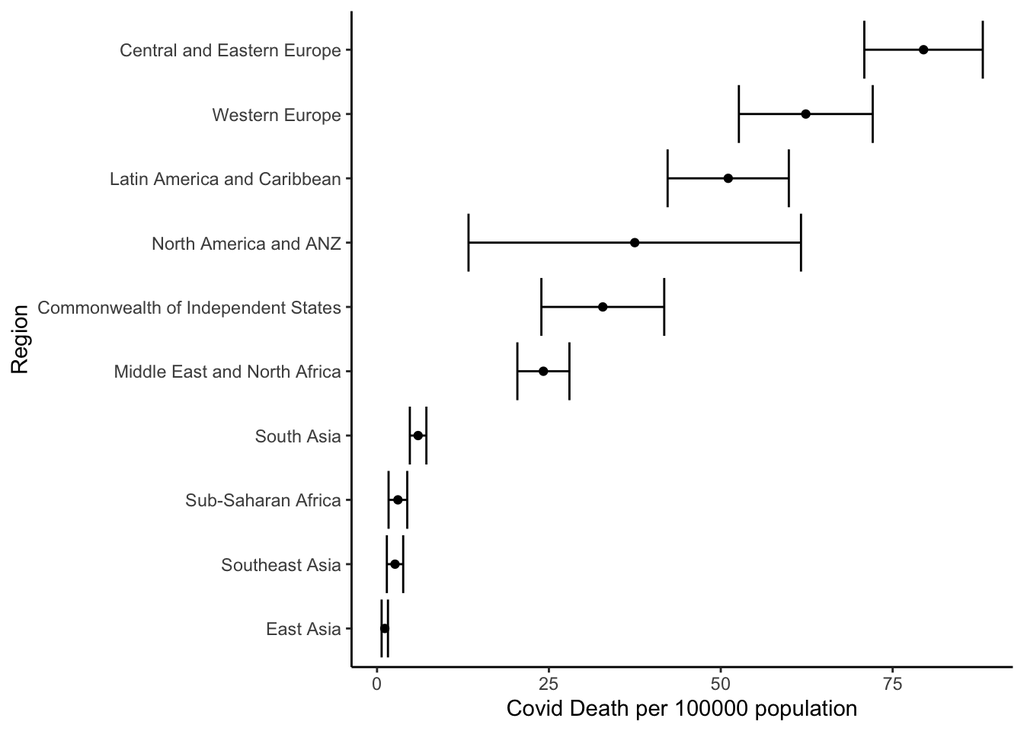

```r
library(ggplot2)
# order by the mean death rate of each region
# set the range of y axis
baseMEANs = ggplot(CovidDeath, aes(x=reorder(Region,DeathRate, mean),
                             y=DeathRate), ylim=c(0,80)) + theme_classic() + xlab("Region") + ylab("Covid Death per 100000 population")

# add error bar
point=baseMEANs + geom_point(stat="summary") + geom_errorbar(stat="summary") + coord_flip()

# show the graph
point
```

```
## No summary function supplied, defaulting to `mean_se()`
## No summary function supplied, defaulting to `mean_se()`
```

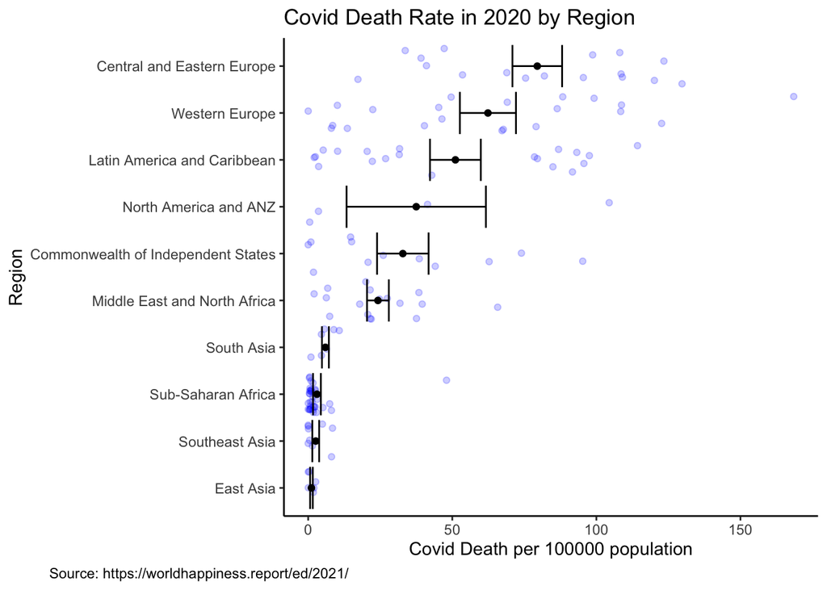

```r
# add the pre-aggregated data in the graph, using dots
jitterMEANs= baseMEANs + geom_jitter(colour="blue",
                             alpha=0.2 #transparency
                             )
jitterMEANs=jitterMEANs + geom_point(stat="summary") +
             geom_errorbar(stat="summary") + coord_flip()
# scale_y_continuous(breaks = c(0, 10, 25, 50, 75))
jitterMEANs=jitterMEANs + labs(title=TitleText, caption=CaptionText) + theme(plot.title = element_text(hjust = 0), plot.caption = element_text(hjust = -1))
jitterMEANs
```

Several Findings: 1) Europe was the most affected areas by the COVID epidemic in terms of death rate in 2020 while Asia was the least affected areas. 2) North America and ANZ has the largest in-group variance, partly due to the small size of countries. Although Europe was hit by the epidemic badly, countries in Europe still ranked high in the happiness ranking.

#### 2. [Practice] Picture of Gini coefficient and median age

The Gini coefficient measures the inequality among values of a frequency distribution (for example, levels of income). A Gini coefficient of zero expresses perfect equality, where all values are the same (e.g. where everyone has the same income). A Gini coefficient of one (or 100%) expresses maximal inequality among values

#### 2.1 data

The two variables are available in the original csv file. The Gini coefficient is coded as “Gini.coefficient.of.income” and the median age is coded as “Median.age”.

Get to know the distribution of Gini coefficient:

```r
summary(WHRData2021$Gini.coefficient.of.income)
```

```
##    Min. 1st Qu.  Median    Mean 3rd Qu.    Max.
##    0.00   31.76   35.96   37.17   43.37   65.43
```

For OECD countries, in the late 20th century, considering the effect of taxes and transfer payments, the income Gini coefficient ranged between 0.24 and 0.49.

#### 2.2 plot the two variables

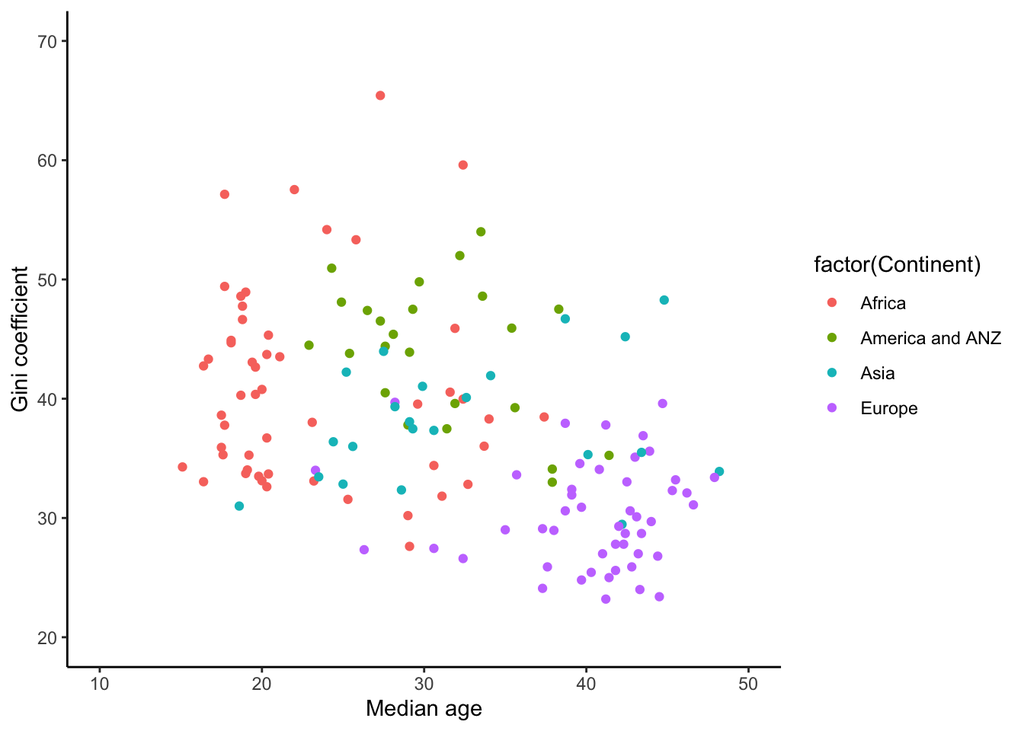

```r
base = ggplot(WHRData2021, aes(x=Median.age,y=Gini.coefficient.of.income)) + theme_classic() + xlab("Median age") + ylab("Gini coefficient")

# set the range of both x and y axis
plot1= base +  geom_point(aes(colour=factor(Continent))) + xlim(c(10,50))+ ylim(c(20,70))
plot1
```

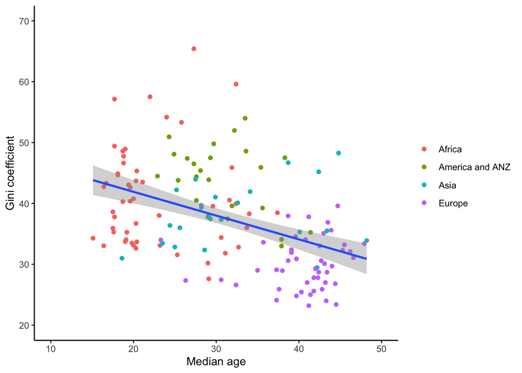

```r
# add the fitted line
plot2 = plot1 + stat_smooth(method='lm') + theme(legend.title=element_blank())
# plot2 = plot1 + stat_smooth(method='lm', se=F) + theme(legend.title=element_blank())
plot2
```

```r
# non-linear
plot3 = plot1 + geom_smooth() + theme(legend.title=element_blank())
# plot3
```

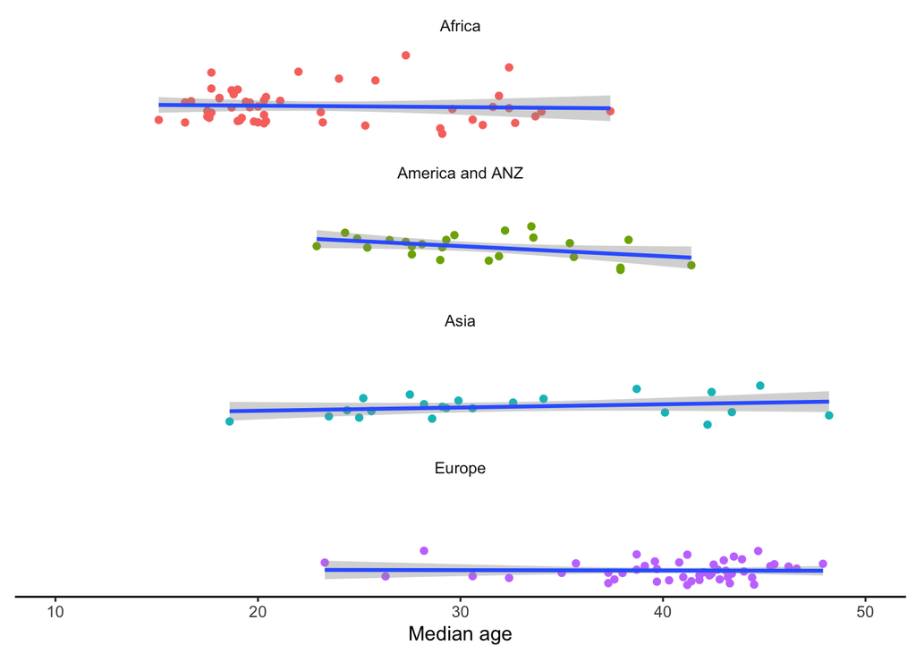

```r
densePlot1 = plot2 + facet_wrap(~Continent,ncol = 1, strip.position = 'top') + theme(legend.position="none")

densePlot1 = densePlot1 + theme(panel.spacing.y = unit(0.1, "lines"),
                              axis.title.y = element_blank(),
                              axis.text.y = element_blank(),
                              axis.line.y = element_blank(),
                              axis.ticks.y = element_blank(),
                              strip.background = element_rect(colour="white"),
                              strip.text.y = element_text(size=10,
                                    color="black",
                                    angle = 0))
densePlot1
```

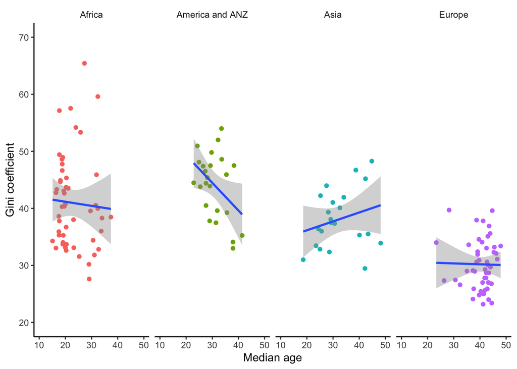

```r
# try col = 4
densePlot2 = plot2 + facet_wrap(~Continent,ncol = 4, strip.position = 'top') + theme(legend.position="none")
densePlot2 = densePlot2 + theme(panel.spacing.y = unit(0.1, "lines"),
                              #axis.title.y = element_blank(),
                              #axis.text.y = element_blank(),
                              #axis.line.y = element_blank(),
                              #axis.ticks.y = element_blank(),
                              strip.background = element_rect(colour="white"),
                              strip.text.y = element_text(size=10,
                                    color="black",
                                    angle = 0))
densePlot2
```

#### 3. [Practice] Picture of GDP per capital and Life Expectancy

A great deal of research has been performed on whether wealth can, in fact, increase happiness. Among the many papers, projects, surveys, and proposals are hypotheses showing varying levels of correlation between per capita GDP and quality of life. These also include several works by recent Nobel laureate, Sir Angus Deaton, a professor Princeton University.

#### 3.1 data

The plot will use the two related variables from the data source.

```r
library(ggrepel)
```

#### 3.2 plot the two variables

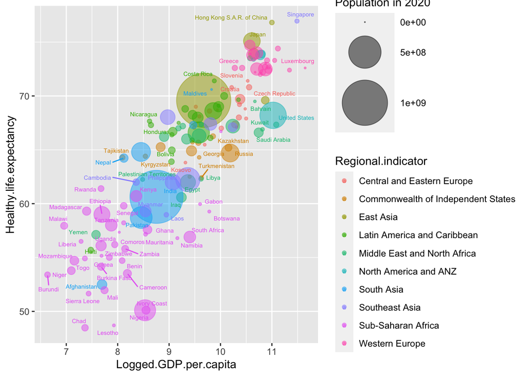

```r
base3 = ggplot(WHRData2021, aes(x=Logged.GDP.per.capita, y=Healthy.life.expectancy, size=Population.2020, color=Regional.indicator)) + geom_point(alpha=0.5)
base3 + scale_size(range=c(.1,24), name="Population in 2020") + geom_text_repel(label=WHRData2021$Country.name, size=2)
```